# Análisis estadístico de datos de Microbioma con R

Existen dos criterios para evaluar si los primeros ejes del PCoA captan o no una cantidad desproporcionadamente grande de la variación total explicada: (1) el *criterio de Kaiser-Guttman* y (2) el *modelo broken-stick*. El *criterio de Kaiser-Guttman* establece que “los valores propios asociados a los primeros ejes deben ser mayores que la media de todos los valores propios”. Según el *criterio del modelo broken-stick*, los valores propios asociados a los primeros ejes se comparan con las expectativas del modelo broken-stick. El *modelo de broken-stick* supone que la suma total de los valores propios disminuye secuencialmente con los ejes PCoA ordenados. Evaluamos el rendimiento de PCoA utilizando estos dos criterios con los siguientes gráficos:

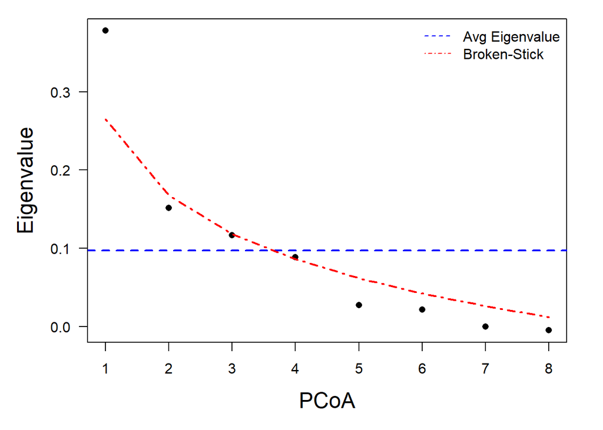

PCoA con el criterio de Kaiser-Guttman y el modelo de broken-stick

```r
# Correr todo junto
# Definir parámetros
par(mar = c(5, 5, 1, 2) + 0.1)
# Graficar eigenvalores
plot(PCoA$eig, xlab = "PCoA", ylab = "Eigenvalue",
     las = 1, cex.lab = 1.5, pch = 16)
#Añadir expextación del criterio de Kaiser-Guttman  y el modelo Broken Stick
abline(h = mean(PCoA$eig), lty = 2, lwd = 2, col = "blue")
b_stick <- bstick(8, sum(PCoA$eig))
lines(1:8, b_stick, type = "l", lty = 4, lwd = 2, col = "red")
# Añadir legendas
legend("topright", legend = c("Avg Eigenvalue", "Broken-Stick"),
       lty = c(2, 4), bty = "n", col = c("blue", "red"))
```

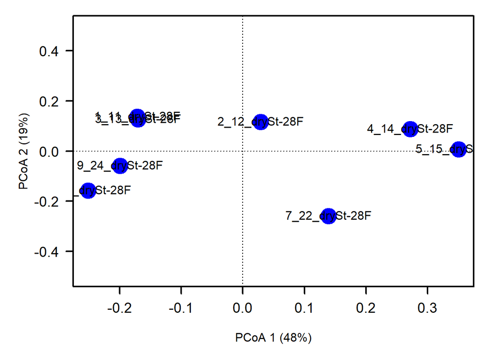

Ordination plot para los dos ejes de PCoA

```r
# Correr todo junto
# Definir parámetros
par(mar = c(5, 5, 1, 2) + 0.1)
# Inicializar el plot
plot(PCoA$points[ ,1], PCoA$points[ ,2], ylim = c(-0.5, 0.5),
     xlab = paste("PCoA 1 (", explainedvar1, "%)", sep = ""),
     ylab = paste("PCoA 2 (", explainedvar2, "%)", sep = ""),
     pch = 5, cex = 1.0, type = "n", cex.lab = 1.0, cex.axis = 1.2, axes = FALSE)
# Añadir ejes
axis(side = 1, labels = T, lwd.ticks = 2, cex.axis = 1.2, las = 1)
axis(side = 2, labels = T, lwd.ticks = 2, cex.axis = 1.2, las = 1)
abline(h = 0, v = 0, lty = 3)
box(lwd = 2)
# Añadir puntos y etiquetas
points(PCoA$points[ ,1], PCoA$points[ ,2],
       pch = 19, cex = 3, bg = "blue", col = "blue")
text(PCoA$points[ ,1], PCoA$points[ ,2],
     labels = row.names(PCoA$points))
```

Los gráficos de ordenación básicos nos permiten ver cómo se separan las muestras entre sí. En nuestro ejemplo, las muestras se separan a lo largo de los ejes PCoA debido a la variación en la abundancia de los diferentes géneros de ratones. Una pregunta lógica de seguimiento es preguntar qué géneros del conjunto de datos están impulsando la divergencia observada entre los puntos. ¿Podemos identificar y visualizar estos géneros influyentes en el PCoA? Podemos obtener esta información utilizando la función `add.spec.scores()` del paquete BiodiversityR. En primer lugar, la abundancia relativa se calcula como sigue:

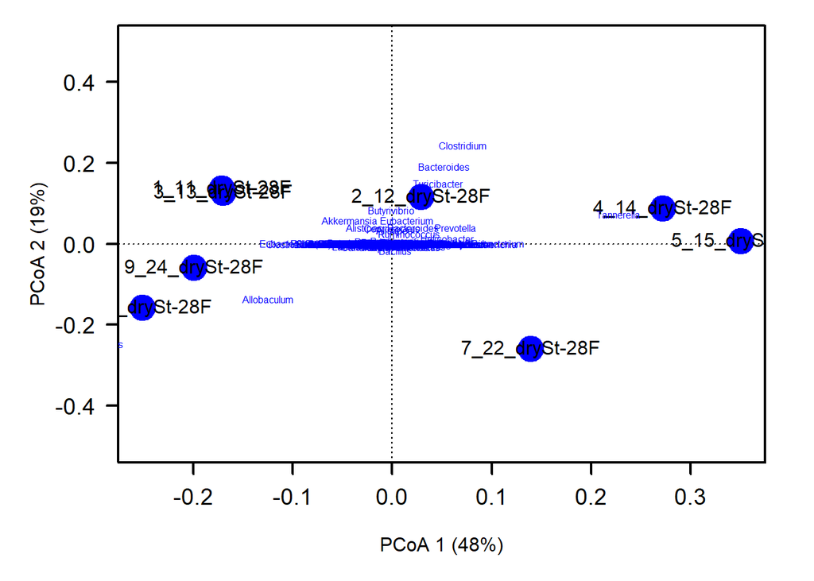

Ordination plot para los dos ejes de PCoA con influencia de genero

```r
# Correr todo junto
# Definir parámetros del plot
par(mar = c(5, 5, 1, 2) + 0.1)
# Inicializar el plot
plot(PCoA$points[ ,1], PCoA$points[ ,2], ylim = c(-0.5, 0.5),
     xlab = paste("PCoA 1 (", explainedvar1, "%)", sep = ""),
     ylab = paste("PCoA 2 (", explainedvar2, "%)", sep = ""),
     pch = 5, cex = 1.0, type = "n", cex.lab = 1.0, cex.axis = 1.2, axes = FALSE)
# Añadir ejes
axis(side = 1, labels = T, lwd.ticks = 2, cex.axis = 1.2, las = 1)
axis(side = 2, labels = T, lwd.ticks = 2, cex.axis = 1.2, las = 1)
abline(h = 0, v = 0, lty = 3)
box(lwd = 2)
# Añadir puntos y etiquetas
points(PCoA$points[ ,1], PCoA$points[ ,2],
       pch = 19, cex = 3, bg = "blue", col = "blue")
text(PCoA$points[ ,1], PCoA$points[ ,2],
     labels = row.names(PCoA$points))

fecalREL <- abund_table
for(i in 1:nrow(abund_table)){
  fecalREL[i, ] = abund_table[i, ] / sum(abund_table[i, ])
}

#install.packages("BiodiversityR")
library("pbkrtest")
library("BiodiversityR")

# Calcular y añadir el score de las especies
PCoA <- add.spec.scores(PCoA,fecalREL,method = "pcoa.scores",Rscale=TRUE,scaling=1, multi=1)
text(PCoA$cproj[ ,1], PCoA $cproj[ ,2],
     labels = row.names(PCoA$cproj),cex=0.5, col = "blue")
```

La función `add.spec.scores()` también puede utilizarse para determinar la correlación de cada taxón a lo largo de los ejes PCoA. Este es un enfoque más efectivamente cuantitativo de identificar los taxones influyentes. Además, para identificar y obtener el taxón más importante, es necesario definir un coeficiente de correlación de corte, en este caso, vamos a tomar $0.7$.

```r
genus_corr <- add.spec.scores(PCoA, fecalREL, method = "cor.scores")$cproj
corrcut <- 0.7 # definir el cutoff
import_genus <- genus_corr[abs(genus_corr[, 1]) >= corrcut | abs(genus_corr[, 2]) >= corrcut, ]
```

Los 12 géneros importantes con correlación mayor o igual a 0,7 a lo largo de los ejes PCoA se imprimen a continuación:

```r
import_genus[complete.cases(import_genus),] %>%
  kbl(booktabs = TRUE, align = "c",
    caption = "Géneros más importantes con correlación mayor o igual a 0.7" )%>%
  kable_styling(position = "center",
                latex_options = c("hold_position",  "striped"),
                font_size = 12)
```

Géneros más importantes con correlación mayor o igual a 0.7

|  | Dim1 | Dim2 |
| --- | --- | --- |
| Tannerella | 0.8205 | 0.1685 |
| Lactobacillus | -0.3064 | -0.8665 |
| Helicobacter | 0.7488 | 0.1176 |
| Paraprevotella | 0.7463 | -0.0858 |
| Bacillus | 0.1980 | -0.7727 |
| Pedobacter | -0.2461 | 0.8703 |
| Limibacter | -0.0824 | 0.7036 |
| Mycoplasma | 0.7227 | 0.2295 |
| Slackia | 0.0977 | -0.7577 |
| Fluviicola | 0.2425 | -0.7107 |
| Caldicellulosiruptor | 0.2425 | -0.7107 |
| Anaerophaga | 0.2425 | -0.7107 |

Por último, utilizamos la función `envfit()` del paquete `vegan` para realizar una prueba de permutación para las abundancias generales a través de los ejes en estas correlaciones.

```r
# Test de permutación para abundancia de especies en los ejes
envfit(PCoA, fecalREL, perm = 999)
```

```
##
## ***VECTORS
##
##                                                                 Dim1   Dim2
## Tannerella                                                     0.951  0.308
## Lactococcus                                                   -0.769 -0.639
## Lactobacillus                                                 -0.219 -0.976
## Lactobacillus::Lactococcus                                    -0.428 -0.904
## Parasutterella                                                -0.754 -0.657
## Helicobacter                                                   0.971  0.241
## Prevotella                                                     0.842  0.540
## Bacteroides                                                    0.262  0.965
## Barnesiella                                                    0.979  0.204
## Odoribacter                                                   -0.537 -0.843
## Eubacterium                                                    0.238  0.971
## Allobaculum                                                   -0.676 -0.737
## Roseburia                                                     -0.044  0.999
## Clostridium                                                    0.280  0.960
## Porphyromonas                                                  0.359 -0.933
## Butyrivibrio                                                  -0.006  1.000
## Ruminococcus                                                   0.557  0.830
## Acholeplasma                                                   0.327  0.945
## Alistipes                                                      0.071  0.997
## Clostridium::Coprococcus                                       0.000  0.000
## Eubacterium (Erysipelotrichaceae)::Eubacterium                -0.820  0.573
## Hydrogenoanaerobacterium                                       0.037 -0.999
## Paraprevotella                                                 0.984 -0.179
## Blautia                                                       -0.087 -0.996
## Adlercreutzia::Asaccharobacter                                -0.140  0.990
## Coprococcus                                                   -0.011  1.000
## Parabacteroides                                                0.978  0.211
## Eubacterium (Erysipelotrichaceae)                             -0.770 -0.639
## Oscillibacter                                                  0.273  0.962
## Acinetobacter                                                  0.999  0.050
## Alkalitalea                                                   -0.622 -0.783
## Sporobacter                                                    0.000  0.000
## Oscillospira                                                   0.481  0.876
## Blautia::Clostridium                                           0.107 -0.994
## Planctomyces                                                  -0.474  0.881
## Akkermansia                                                   -0.587  0.809
```

[output cut: 450 more lines]

```
## Sporobacterium::Clostridium                                   0.00  1.000
## Butyrivibrio::Roseburia                                       0.00  1.000
## Luteococcus                                                   0.00  1.000
## Clostridium::Blautia::Desulfotomaculum                        0.10  1.000
## Lachnospira::Ruminococcus                                     0.10  1.000
## Ornithinimicrobium                                            0.00  1.000
## Persicivirga                                                  0.00  1.000
## Lachnospira::Ruminococcus::Escherichia                        0.00  1.000
## Anaerophaga                                                   0.56  0.122
## Dysgonomonas::Flavobacterium                                  0.00  1.000
## Bizionia                                                      0.10  1.000
## ---
## Signif. codes:  0 '***' 0.001 '**' 0.01 '*' 0.05 '.' 0.1 ' ' 1
## Permutation: free
## Number of permutations: 999
```

Los géneros con un $p-$valor menor a $0.05$ se muestran con el siguiente gráfico.

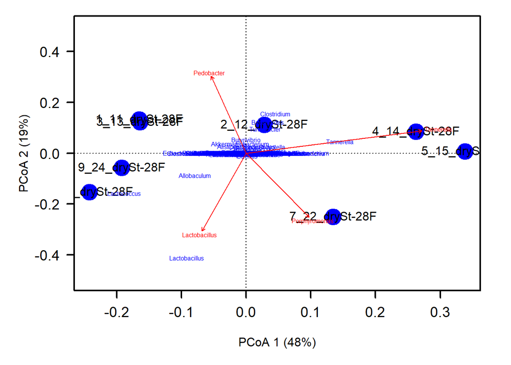

Ordination plot para los dos ejes de PCoA de influencia de genero con un $p-$valor $<0.05$

```r
# Correr todo junto
# Definir los parámetros del plot
par(mar = c(5, 5, 1, 2) + 0.1)
# Inicializar el plot
plot(PCoA$points[ ,1], PCoA$points[ ,2], ylim = c(-0.5, 0.5),
     xlab = paste("PCoA 1 (", explainedvar1, "%)", sep = ""),
     ylab = paste("PCoA 2 (", explainedvar2, "%)", sep = ""),
     pch = 5, cex = 1.0, type = "n", cex.lab = 1.0, cex.axis = 1.2, axes = FALSE)
# Añadir ejes
axis(side = 1, labels = T, lwd.ticks = 2, cex.axis = 1.2, las = 1)
axis(side = 2, labels = T, lwd.ticks = 2, cex.axis = 1.2, las = 1)
abline(h = 0, v = 0, lty = 3)
box(lwd = 2)
# Añadir puntos y etiquetas
points(PCoA$points[ ,1], PCoA$points[ ,2],
       pch = 19, cex = 3, bg = "blue", col = "blue")
text(PCoA$points[ ,1], PCoA$points[ ,2],
     labels = row.names(PCoA$points))

fecalREL <- abund_table
for(i in 1:nrow(abund_table)){
  fecalREL[i, ] = abund_table[i, ] / sum(abund_table[i, ])
}

#install.packages("BiodiversityR")
library("pbkrtest")
library("BiodiversityR")

# Calcular y añadir el score de las especies
PCoA <- add.spec.scores(PCoA,fecalREL,method = "pcoa.scores",Rscale=TRUE,scaling=1, multi=1)
text(PCoA$cproj[ ,1], PCoA $cproj[ ,2],
     labels = row.names(PCoA$cproj),cex=0.5, col = "blue")


genus_corr <- add.spec.scores(PCoA, fecalREL, method = "cor.scores")$cproj
corrcut <- 0.7 # definir el cutoff
import_genus <- genus_corr[abs(genus_corr[, 1]) >= corrcut | abs(genus_corr[, 2]) >= corrcut, ]

# Código para los generos con un p-valor<0.05

fit <- envfit(PCoA, fecalREL, perm = 999)
plot(fit, p.max = 0.05, cex=0.5, col = "red")
```

### Escalamiento multidimensional no métrico (NMDS)

El *NMDS* es la alternativa no métrica al análisis PCoA. El NMDS ha sido reconocido como un buen método de ordenación porque utiliza formas ecológicamente significativas para medir las *disimilitudes* de las comunidades y cualquier medida de distancia (disimilitudes) entre las muestras como entrada. Por ello, es el método recomendado en la ordenación de comunidades. El objetivo principal del análisis NMDS es *proyectar la posición relativa de los puntos de la muestra en un espacio de ordenación de baja dimensión* (dos o tres ejes).

La función `metaMDS()` del paquete `vegan` realiza el análisis NMDS. Para simplificar, el algoritmo del análisis NMDS se resume como sigue: en primer lugar, utiliza la función `vegdist()` para obtener las medidas de disimilitud adecuadas; a continuación, ejecuta NMDS varias veces con configuraciones iniciales aleatorias y compara los resultados mediante la función `procrustes()`, y se detiene tras encontrar dos veces una solución mínima similar. Por último, escala y rota la solución, y añade las puntuaciones de las especies (o OTUs/taxa) a la configuración como promedios ponderados utilizando la función `wascores()`. Una vez finalizado el algoritmo, la solución final se rota utilizando PCA para facilitar su interpretación.

En este caso, utilizamos el paquete `vegan` y los mismos datos fecales de ratones Vdr-/- para ilustrar análisis NMDS. En primer lugar, utilizamos la función `vegdist()` para obtener las medidas de disimilitud de *Bray-Curtis (el método por defecto)* utilizando la configuración por defecto de la función `metaMDS()`. Esta función transforma automáticamente los datos y comprueba la solidez de la solución. La doble estandarización de **Wisconsin** y la transformación **sqrt** se utilizaron conjuntamente en la llamada a la función `metaMDS()`. La llamada a la función produce un valor de tensión del 7,57%.

```r
bc_nmds <- metaMDS(abund_table, dist = "bray")
```

```
## Square root transformation
## Wisconsin double standardization
## *** Solution reached
```

```r
bc_nmds
```

```
##
## Call:
## metaMDS(comm = abund_table, distance = "bray")
##
## global Multidimensional Scaling using monoMDS
##
## Data:     wisconsin(sqrt(abund_table))
## Distance: bray
##
## Dimensions: 2
## Stress:     0.07574
## Stress type 1, weak ties
## Two convergent solutions found after 20 tries
## Scaling: centring, PC rotation, halfchange scaling
## Species: expanded scores based on 'wisconsin(sqrt(abund_table))'
```

En segundo lugar, utilizamos la función `ordiplot()` para dibujar los resultados del NMDS. La configuración por defecto sólo añade puntos a la figura, utilizamos `type = 't'` o `type = 'text'` para añadir etiquetas de texto en esta figura.

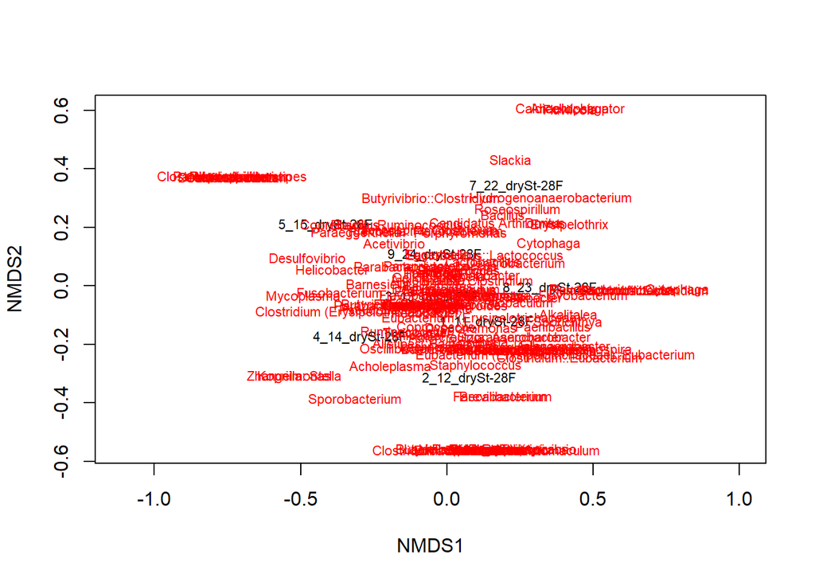

Ordiplot de dos ejes de NMDS con etiquetas

```r
ordiplot (bc_nmds, type = 't')
```

Para trazar las puntuaciones del sitio (muestra) como texto:

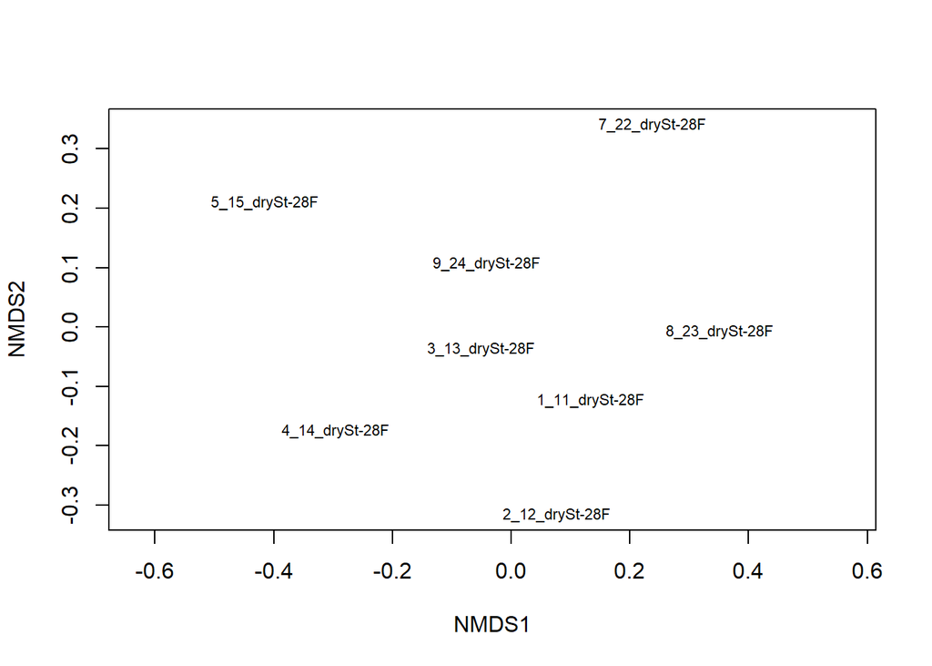

Ordiplot de dos ejes de NMDS con etiquetas de las muestras

```r
ordiplot(bc_nmds, display = "sites", type = "text")
```

Finalmente, la función `stressplot()` se utiliza para dibujar el gráfico de *estrés de Shepards*. La función `stressplot()` genera dos figuras: una traza las distancias de ordenación frente a la disimilitud observada (las disimilitudes de la comunidad elegida), junto con una línea de paso monótona para mostrar el ajuste; otra traza la bondad del ajuste para evaluar la bondad de la ordenación de NMDS2 frente a NMDS1 de muestras concretas. Primero, dividimos la ventana de trazado en dos paneles. La función `plot()` dibuja el diagrama de ordenación NMDS con los sitios (muestras). La función `points()` añade los puntos con un tamaño que refleja la bondad del ajuste (mayor = peor ajuste).

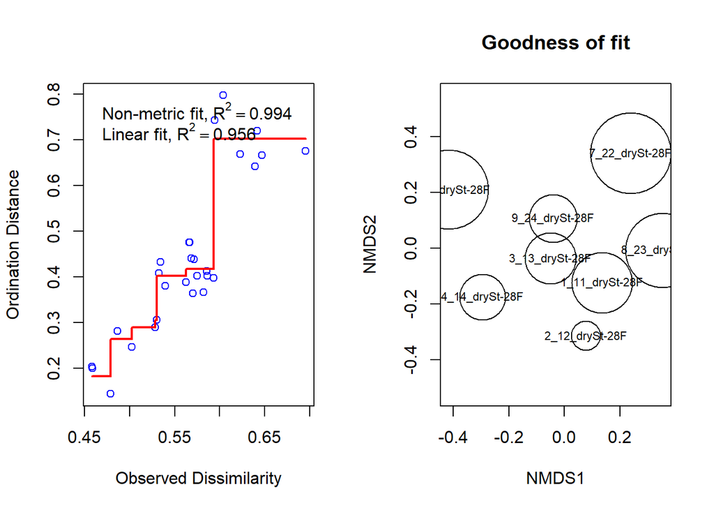

Gráfico del strés de Shepards y de la bondad de ajuste

```r
par (mfrow = c(1,2))
stressplot (bc_nmds)
plot (bc_nmds, display = 'sites', type = 't', main = 'Goodness of fit')
points (bc_nmds, display = 'sites', cex = goodness (bc_nmds)*300)
```

El stressplot muestra la relación entre las distancias reales entre las muestras en solución de ordenación de dimensión $m$, y sus disimilitudes composicionales particulares expresadas por la medida de disimilitud de *Bray-Curtis*. Existen dos estadísticas de bondad de ajuste similares a la correlación; la correlación basada en la tensión $R^2 = 1 - S^2$ (ajuste no métrico $= 0.994$) y la correlación entre los valores ajustados y las distancias de ordenación, o entre la línea de paso y los puntos: “$R^2$ basado en el ajuste” (ajuste lineal $= 0,956$).

### Análisis de correspondencia (AC)

CA es otro método de ordenación sin restricciones. Utiliza las *distancias chi-cuadrado* entre las muestras en el espacio multidimensional de todos los ejes de ordenación y da un alto peso a las especies raras (por ejemplo, especies de baja ocurrencia con muchos ceros). Al igual que PCA y PCoA, CA utiliza los valores propios para medir la importancia de los ejes ortogonales devueltos.

En el diagrama de ordenación del PCA, los taxones son vectores y las muestras son puntos, mientras que en el CA, los taxones y las muestras están representados por puntos. Al igual que PCA, CA tiene dos tipos de escalas: Escalas 1 y 2. En el espacio de ordenación reducido, *las distancias entre las muestras* (Escala 1) se aproximan a su *distancia chi-cuadrado*. Por ejemplo, cualquier muestra cercana al punto que representa un taxón probablemente contiene una alta contribución a ese taxón. Las *distancias entre taxones* (Escala 2) también se aproximan a sus *distancias chi-cuadrado*. Por ejemplo, cualquier taxón cercano al punto que representa una muestra probablemente tenga una mayor frecuencia en esa muestra. La función `cca()` del paquete `vegan` puede utilizarse para realizar un análisis de correspondencia sin restricciones. Utilizamos la función `cca()` para realizar el CCA y la función `evplot()` para seleccionar ejes de ordenación importantes basados en el criterio de *Kaiser-Guttman* o modelo de *broken-stick*. La función `evplot()`, escrita por Borcard et al. (2011), se utiliza aquí para trazar los valores propios y los porcentajes de variación de un objeto de ordenación. Cuando se utiliza la función `cca()` (cca = análisis canónico compoente) para realizar CA sin restricciones, no se especifica la matriz ambiental ni la información de agrupación.

```r
fecal_genus_cca=cca(abund_table)
fecal_genus_cca
```

```
## Call: cca(X = abund_table)
##
##               Inertia Rank
## Total           0.502
## Unconstrained   0.502    7
## Inertia is scaled Chi-square
## 122 species (variables) deleted due to missingness
##
## Eigenvalues for unconstrained axes:
##    CA1    CA2    CA3    CA4    CA5    CA6    CA7
## 0.2036 0.1256 0.0747 0.0374 0.0322 0.0200 0.0090
```

La heterogeneidad total de los datos (inercia) es de 0.502, y el primer eje capta 40.5638% de la variación total en la composición del género (0.2036 / 0.502 = 0.4056, donde 0.2036 es el valor propio del primer eje CA1, y 0.502 es la heterogeneidad total de los datos).

Los siguientes códigos de R se utilizan para trazar la ordenación y mostrar los nombres de las muestras en la figura:

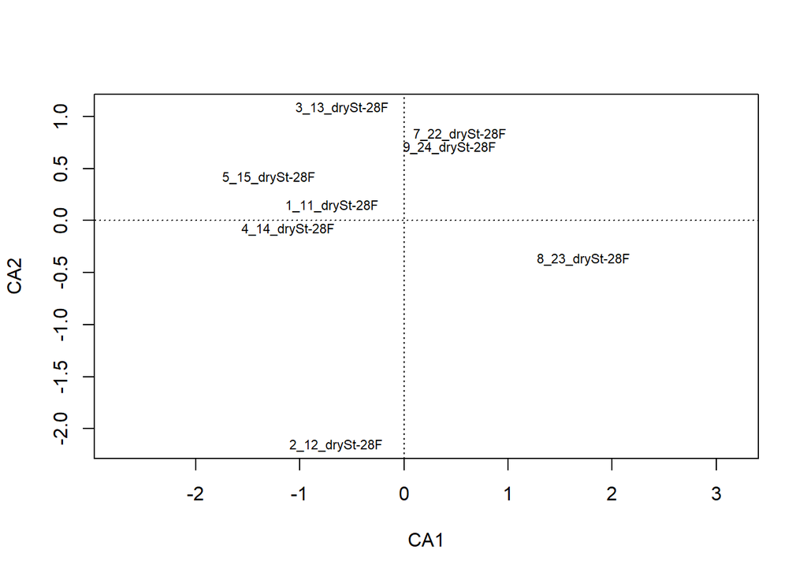

Plot de ordenación con muestras.

```r
plot(fecal_genus_cca, display="sites")
```

Si no quiere que el gráfico esté sobrecargado, utilice los siguientes códigos de R para sólo mostrar puntos en lugar de nombres de muestras en la figura:

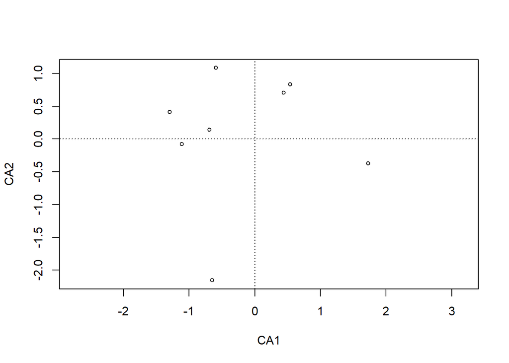

Plot de ordenación sin etiquetas de las muestras

```r
plot(fecal_genus_cca, display="sites", type="p")
```

El siguiente diagrama de ordenación revela el patrón de muestras y géneros en diagrama de ordenación:

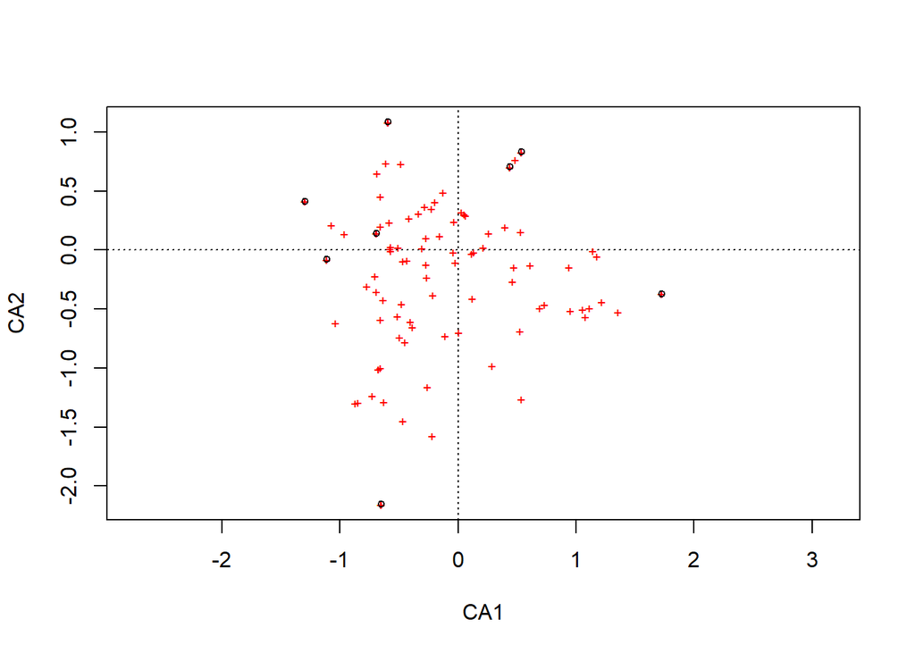

Plot de ordenación, muestra los patrones de las muestras y generos en el diagrama de ordenación. Los círculos representan las muestras y los signos + representan los géneros.

```r
ordiplot(fecal_genus_cca)
```

El siguiente análisis posterior a la CA utilizando la función `evplot()` es para ilustrar cómo decidir qué eje de CA debe utilizarse para la interpretación de los resultados. La sintaxis de la función función `evplot()` es `evplot(ev)`, donde ev es un vector de valores propios. En primer lugar, ejecutamos la función.

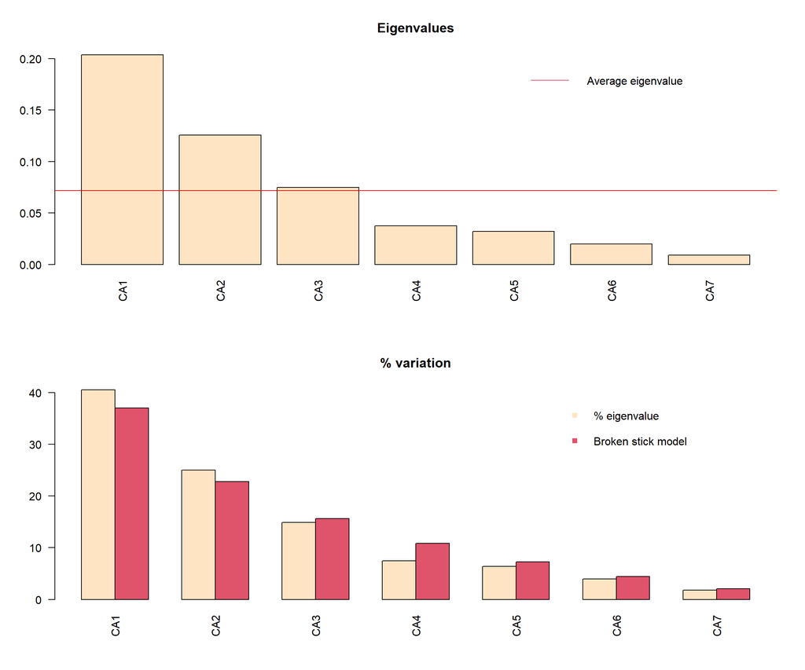

Eigenvalores y porcentajes de variación del criterio Keiser-Guttman y el modelo broken-stick

```r
evplot <- function(ev)
{# Broken stick model (MacArthur 1957)
  n <- length(ev)
  bsm <- data.frame(j=seq(1:n), p=0)
  bsm$p[1] <- 1/n
  for (i in 2:n) bsm$p[i] <- bsm$p[i-1] + (1/(n + 1 - i))
  bsm$p <- 100*bsm$p/n
  # Graficar eigenvalores y porcentaje de varianza en cada eje
  op <- par(mfrow=c(2,1))
  barplot(ev, main="Eigenvalues", col="bisque", las=2)
  abline(h=mean(ev), col="red")
  legend("topright", "Average eigenvalue", lwd=1, col=2, bty="n")
  barplot(t(cbind(100*ev/sum(ev), bsm$p[n:1])), beside=TRUE,
          main="% variation", col=c("bisque",2), las=2)
  legend("topright", c("% eigenvalue", "Broken stick model"),
         pch=15, col=c("bisque",2), bty="n")
  par(op)
}

# Plot de eigenvalores y porcentaje de varianza en cada eje
ev <- fecal_genus_cca$CA$eig

windows(title="CA eigenvalues")
evplot(ev)
```

## Ordenaciones restringidas

Como contrapartida a los tres métodos básicos de ordenación, el paquete `vegan` cuenta con tres versiones de ordenación restringida:

- Análisis de redundancia (RDA, relacionado con el análisis de componentes principales)
- Análisis restringido de coordenadas principales (CAP, relacionado con el escalado métrico)
- Análisis restringido de correspondencia (CCA, relacionado con el análisis de correspondencia).

### Análisis de redundancia (RDA)

El RDA en la función `rda()` se basa en las distancias euclidianas y combina la regresión múltiple con el PCA. Con RDA, cada eje canónico es una combinación lineal de todas las variables explicativas. El número de ejes canónicos corresponde al número de variables explicativas, o más exactamente al número de grados de libertades (Borcard et al. 2011).

Puede utilizar dos sintaxis diferentes para calcular una RDA mediante la función `rda()` de `vegan`: sintaxis matricial y sintaxis de fórmula. La sintaxis matricial es la más sencilla: basta con enumerar los nombres de los objetos separados por comas como se indica a continuación. `RDA = rda(Y, X, W)`, donde Y es la matriz de respuesta (composición de taxones), X es la matriz explicativa (factores ambientales) y W es la matriz opcional de covariables.

La sintaxis de fórmula esta dada como:

`RDA = rda(Y ~ var1 + factor A + var2 * var3 + condition(var4), data = XW)`

donde `Y` es la matriz de respuesta (composición de taxones); y las variables del lado derecho de la fórmula son las variables explicatorias o restringidas. El objeto `XW` es un dataframe con las variables explicatorias o covariables.

La prueba de hipótesis no es el caso en PCA. Sin embargo, con dos conjuntos de datos $Y$ y $X$, en RDA podemos probar una hipótesis nula de ausencia de relación lineal entre entre ellos. Utilizamos el conjunto de datos de fumadores para ilustrar el uso de RDA. Primero, cargue los datos del paquete GUniFrac y utilice la función `select()` del paquete *dplyr* para crear un subconjunto de variables explicativas.

```r
library("GUniFrac")
data(throat.otu.tab)
data(throat.meta)

library("dplyr")
throat_meta <- select(throat.meta, SmokingStatus, Age, Sex, PackYears)
```

A efectos de RDA, transformamos los datos de los taxones utilizando la transformación de Hellinger:

```r
library("vegan")  # Solo si no se ha cargado antes
abund_hell <- decostand (throat.otu.tab, 'hell')
```

La RDA se calcula con la función `rda()` si se suministra la matriz de variables ambientales (si no, se calculará el ACP)

```r
rda_hell<- rda(abund_hell ~ ., throat_meta)
head(summary (rda_hell))
```

```
##
## Call:
## rda(formula = abund_hell ~ SmokingStatus + Age + Sex + PackYears,      data = throat_meta)
##
## Partitioning of variance:
##               Inertia Proportion
## Total          0.4627      1.000
## Constrained    0.0482      0.104
## Unconstrained  0.4145      0.896
##
## Eigenvalues, and their contribution to the variance
##
## Importance of components:
##                         RDA1   RDA2    RDA3    RDA4    PC1    PC2    PC3
## Eigenvalue            0.0239 0.0133 0.00597 0.00504 0.0683 0.0595 0.0355
## Proportion Explained  0.0517 0.0287 0.01290 0.01089 0.1476 0.1285 0.0768
## Cumulative Proportion 0.0517 0.0805 0.09335 0.10424 0.2518 0.3803 0.4572
##                         PC4    PC5    PC6    PC7    PC8    PC9    PC10
## Eigenvalue            0.024 0.0174 0.0156 0.0149 0.0122 0.0103 0.00965
## Proportion Explained  0.052 0.0376 0.0337 0.0322 0.0263 0.0223 0.02086
## Cumulative Proportion 0.509 0.5467 0.5804 0.6126 0.6390 0.6613 0.68212
##                          PC11    PC12    PC13    PC14    PC15    PC16    PC17
## Eigenvalue            0.00924 0.00876 0.00775 0.00671 0.00648 0.00626 0.00597
## Proportion Explained  0.01998 0.01893 0.01674 0.01450 0.01399 0.01352 0.01291
## Cumulative Proportion 0.70210 0.72103 0.73777 0.75226 0.76626 0.77978 0.79269
##                          PC18    PC19   PC20    PC21    PC22    PC23    PC24
## Eigenvalue            0.00549 0.00529 0.0050 0.00459 0.00435 0.00400 0.00372
## Proportion Explained  0.01187 0.01144 0.0108 0.00993 0.00939 0.00865 0.00804
## Cumulative Proportion 0.80455 0.81599 0.8268 0.83673 0.84612 0.85477 0.86281
##                          PC25    PC26    PC27    PC28    PC29    PC30    PC31
## Eigenvalue            0.00361 0.00357 0.00338 0.00323 0.00314 0.00307 0.00296
## Proportion Explained  0.00780 0.00771 0.00730 0.00698 0.00678 0.00663 0.00639
## Cumulative Proportion 0.87062 0.87832 0.88562 0.89260 0.89938 0.90601 0.91240
##                          PC32    PC33    PC34    PC35    PC36    PC37    PC38
## Eigenvalue            0.00285 0.00268 0.00249 0.00232 0.00225 0.00218 0.00213
## Proportion Explained  0.00617 0.00579 0.00537 0.00502 0.00486 0.00471 0.00460
## Cumulative Proportion 0.91857 0.92435 0.92973 0.93475 0.93961 0.94431 0.94891
##                          PC39    PC40    PC41    PC42    PC43    PC44    PC45
## Eigenvalue            0.00198 0.00186 0.00176 0.00168 0.00163 0.00155 0.00151
## Proportion Explained  0.00427 0.00403 0.00380 0.00364 0.00353 0.00335 0.00327
```

[output cut: 60 more lines]

```
##
##                      RDA1    RDA2   RDA3   RDA4 PC1 PC2
## SmokingStatusSmoker 0.906 -0.3399 -0.135 0.2110   0   0
## Age                 0.228 -0.0442  0.748 0.6217   0   0
## SexMale             0.496  0.8360  0.103 0.2110   0   0
## PackYears           0.658 -0.1515  0.738 0.0222   0   0
##
##
## Centroids for factor constraints
##
##                          RDA1    RDA2    RDA3    RDA4 PC1 PC2
## SmokingStatusNonSmoker -0.250  0.0938  0.0374 -0.0582   0   0
## SmokingStatusSmoker     0.286 -0.1072 -0.0427  0.0665   0   0
## SexFemale              -0.199 -0.3362 -0.0413 -0.0848   0   0
## SexMale                 0.107  0.1810  0.0222  0.0457   0   0
```

Los cuatro ejes de ordenación restringidos (denominados RDA1 a RDA4) están relacionados con las 4 variables ambientales (SmokingStatus, Age, Sex, PackYears). Los ejes no restringidos se denominan ejes PC.

La función `coef()` recupera los coeficientes canónicos (el equivalente a coeficientes de regresión) para cada variable explicativa en cada eje canónico.

```r
coef(rda_hell)
```

```
##                          RDA1      RDA2      RDA3     RDA4
## SmokingStatusSmoker  0.177040 -0.120402 -0.187134  0.15184
## Age                 -0.004452 -0.002161  0.002997  0.01757
## SexMale              0.092005  0.267873 -0.027579  0.01856
## PackYears            0.005257 -0.000520  0.011633 -0.01596
```

Podemos utilizar la función `RsquareAdj()` para extraer el valor de $R^2$ y el ajustado $R^2$ de los resultados de la ordenación.

```r
RsquareAdj(rda_hell)
```

```
## $r.squared
## [1] 0.1042
##
## $adj.r.squared
## [1] 0.03909
```

La función devuelve dos $R^2$: uno es el $R^2$ ordinario (r.al cuadrado), otro es el $R^2_{adj}$ ajustado. Tenga en cuenta que $R^2_{adj}$ es siempre menor que el $R^2$, y la diferencia aumenta con el aumento del número de variables explicativas. El $R^2_{adj}$ puede ser negativo, lo que significa que las variables explicativas explican menos variación que el mismo número de variables generadas al azar.

Aplicamos el criterio de Kaiser-Guttman a los ejes residuales.

```r
rda_hell$CA$eig[rda_hell$CA$eig > mean(rda_hell$CA$eig)]
```

```
##      PC1      PC2      PC3      PC4      PC5      PC6      PC7      PC8
## 0.068299 0.059456 0.035542 0.024040 0.017406 0.015601 0.014898 0.012182
##      PC9     PC10     PC11     PC12     PC13
## 0.010314 0.009654 0.009245 0.008760 0.007745
```

A continuación, trazamos los resultados de la RDA. En función de la ordenación que le interese, puede elegir trazar el escalado tipo 1 o el escalado tipo 2. Para la *ordenación de las muestras*, el escalamiento 1 es la opción más adecuada. Para la *ordenación de los taxones*, entonces, el escalamiento 2 es el más apropiado.

El *escalamiento de tipo 1* hace hincapié en las relaciones entre las muestras. Las características esenciales (Borcard et al. 2011; Legendre y Legendre 2012) son que las muestras actúan como los centroides de las variables de respuesta (columnas) y las distancias entre los puntos de las muestras indican sus distancias $\chi^2$. La interpretación se basa en que:

1. Los puntos de muestra que están cerca unos de otros probablemente sean relativamente similares en cuanto a sus frecuencias relativas.
2. Las muestras cercanas a los centroides que representan estados de variables categóricas o cualitativas tienen más probabilidades de poseer el estado para esa especie/taxón.
3. Una proyección en ángulo recto de un punto de muestra sobre un vector que representa una variable cuantitativa cuantitativa se aproxima al valor de la variable realizada para esa muestra.

El *escalamiento de tipo 2* hace hincapié en las relaciones entre las variables de respuesta. Las características esenciales son que las variables de respuesta (columnas) actúan como los centroides de las muestras y las distancias entre los puntos de las variables de respuesta indican sus distancias $\chi^2$. La interpretación se basa en que:

1. Los puntos de especies/taxones que están cerca unos de otros entre sí es probable que tengan frecuencias relativas similares a lo largo de las muestras.
2. Cuanto más cerca una variable de respuesta (una especie/taxón) al centroide que representa un estado de una categórica, es más probable que esa variable de respuesta tenga valores más altos en ese estado.
3. Una proyección en ángulo recto de un punto que representa una respuesta (una especie/taxón) sobre una flecha que representa una variable explicativa indica la posición del valor máximo (el óptimo) de la variable de respuesta a lo largo de esa variable explicativa.

En la ordenación restringida, se dispone de una fuente de datos adicional para el trazado: *las variables explicativas (ambientales)*. Así, se dispone de tres datos diferentes para muestras, variables de respuesta y variables explicativas. Si se muestran todos los datos de las tres fuentes, se tiene un **“triplot”**. Si muestra los datos de dos fuentes, tiene **biplot**. Los siguientes códigos de R generan un triplot de escala de tipo 2:

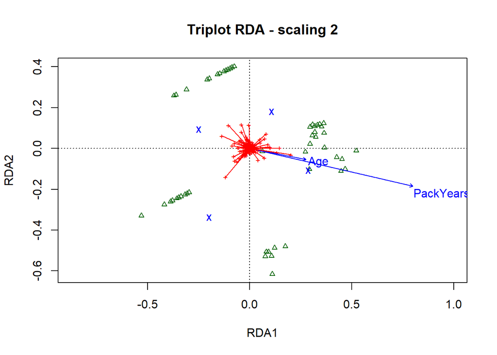

Triplot RDA con escalado tipo 2

```r
plot(rda_hell, display=c("sp", "lc", "cn"),main="Triplot RDA - scaling 2")
taxa_scores <- scores(rda_hell, choices=c(1,2), display="sp")
arrows(0, 0, taxa_scores[,1], taxa_scores[,2], length=0, lty=1, col="red")
```

Para comprobar la importancia de la variación de los datos de la comunidad de fumadores explicada por las variables explicativas, podemos realizar una prueba de permutación de Monte Carlo mediante la función función `anova.cca()` del paquete `vegan`. Esta función puede probar la significancia del modelo global (por defecto), todos los ejes (`by = "axis"`), las variables explicativas individuales (`by = "terms"`), el primer eje restringido (`first = TRUE`), o la variación explicada por variables explicativas individuales después de eliminar la variación de todas las demás variables en el modelo (`by = "margin"`). Ilustramos su capacidad probando el modelo global, cada eje y cada variable explicativa, respectivamente.

Para asegurarnos de obtener el mismo resultado de la prueba de permutación cada vez que se ejecute, establecemos primero la misma semilla. Los siguientes códigos R prueban la significación del modelo global. El argumento “paso” especifica el número mínimo de permutaciones.

```r
set.seed (123)
anova(rda_hell, step=1000) %>%
  kbl(booktabs = TRUE, align = "c",
    caption = "ANOVA global")%>%
  kable_styling(position = "center",
                latex_options = c("hold_position",  "striped"),
                font_size = 12)
```

ANOVA global

|  | Df | Variance | F | Pr(>F) |
| --- | --- | --- | --- | --- |
| Model | 4 | 0.0482 | 1.6 | 0.004 |
| Residual | 55 | 0.4145 | NA | NA |

Podemos observar que el test global es estadísticamente significante. Ahora, vamos a ver el test en cada eje.

```r
set.seed (123)
anova(rda_hell, by="axis", step=1000)%>%
  kbl(booktabs = TRUE, align = "c",
    caption = "ANOVA test para todos los ejes")%>%
  kable_styling(position = "center",
                latex_options = c("hold_position",  "striped"),
                font_size = 12)
```

ANOVA test para todos los ejes

|  | Df | Variance | F | Pr(>F) |
| --- | --- | --- | --- | --- |
| RDA1 | 1 | 0.0239 | 3.1754 | 0.013 |
| RDA2 | 1 | 0.0133 | 1.7644 | 0.256 |
| RDA3 | 1 | 0.0060 | 0.7920 | 0.942 |
| RDA4 | 1 | 0.0050 | 0.6686 | 0.876 |
| Residual | 55 | 0.4145 | NA | NA |

```r
set.seed (123)
anova(rda_hell, by="terms", step=1000)%>%
  kbl(booktabs = TRUE, align = "c",
    caption = "ANOVA test para variables explicativas")%>%
  kable_styling(position = "center",
                latex_options = c("hold_position",  "striped"),
                font_size = 12)
```

ANOVA test para variables explicativas

|  | Df | Variance | F | Pr(>F) |
| --- | --- | --- | --- | --- |
| SmokingStatus | 1 | 0.0215 | 2.8571 | 0.002 |
| Age | 1 | 0.0057 | 0.7512 | 0.773 |
| Sex | 1 | 0.0144 | 1.9171 | 0.019 |
| PackYears | 1 | 0.0066 | 0.8751 | 0.588 |
| Residual | 55 | 0.4145 | NA | NA |

Aquí podemos observar que tanto `SmokingStatus` como `Sex` son significativas.

Por último, utilizamos la selección directa para reducir el número de variables explicativas que entran en el análisis, mientras se optimiza la variación explicada por ellas.

Actualmente, hay tres funciones disponibles en RDA para la selección hacia adelante: `ordistep()`, `ordiR2step()`, y `forward.sel()`.Las dos primeras funciones son del paquete `vegan`. La tercera, está disponible en el paquete `adespatial`. Estas funciones utilizan diferentes criterios para la selección de variables. La función `ordistep()` utiliza el criterio AIC y los $p-$valores de la prueba de permutación de Monte Carlo para la comparación de variables. La función `ordiR2step()` utiliza $R_{adj}^2$. La función `forward.sel()` utiliza el nivel de significación preseleccionado de $\alpha$ como criterio de selección de variables.

Aunque la función `forward.sel()` tiene una lógica diferente para establecer los argumentos comparada con las otras dos funciones, básicamente los resultados devueltos son los mismos que `ordiR2step()`. Por lo tanto, sólo ilustramos las dos primeras funciones. El procedimiento `ordistep()` es aplicable con las funciones `rda()`, `cca()` o `cmdscale()`. El procedimiento `ordiR2step()` sólo puede aplicarse a `rda()` y `capscale()`, pero no para `cca()` porque `cca()` no devuelve $R_{adj}^{2}$.

Los siguientes códigos de R utilizan la función `ordistep()` para ejecutar la selección hacia adelante. También se dispone de opciones para la selección por pasos y hacia atrás. Esta función permite el uso de factores.

```r
step_forward <- ordistep(rda(abund_hell ~ 1, data=throat_meta),
                         scope=formula(rda_hell), direction="forward", pstep=1000)
```

```
##
## Start: abund_hell ~ 1
##
##                 Df   AIC    F Pr(>F)
## + SmokingStatus  1 -46.1 2.83  0.005 **
## + Sex            1 -45.3 2.01  0.015 *
## + PackYears      1 -45.1 1.80  0.050 *
## + Age            1 -44.1 0.83  0.570
## ---
## Signif. codes:  0 '***' 0.001 '**' 0.01 '*' 0.05 '.' 0.1 ' ' 1
##
## Step: abund_hell ~ SmokingStatus
##
##             Df   AIC    F Pr(>F)
## + Sex        1 -46.0 1.87   0.04 *
## + PackYears  1 -45.0 0.87   0.63
## + Age        1 -44.9 0.74   0.78
## ---
## Signif. codes:  0 '***' 0.001 '**' 0.01 '*' 0.05 '.' 0.1 ' ' 1
##
## Step: abund_hell ~ SmokingStatus + Sex
##
##             Df   AIC    F Pr(>F)
## + PackYears  1 -45.0 0.85   0.66
## + Age        1 -44.9 0.81   0.66
```

Este procedimiento elige las variables `SmokingStatus` y `Sex`. La siguiente selección utiliza la función `ordiR2step()`. La configuración por defecto de este procedimiento para incluir una nueva variable se basa en $R^2_{adj}$ y su comparación con la del modelo global (con todas las variables). La selección se detendrá si la nueva variable no es significativa o el $R_{adj}^2$ del modelo que incluye esta nueva variable superaría el $R_{adj}^{2}$ del modelo global.

```r
step_forward <- ordiR2step(rda(abund_hell ~ 1, data=throat_meta),
                           scope=formula(rda_hell), direction="forward", pstep=1000)
```

```
## Step: R2.adj= 0
## Call: abund_hell ~ 1
##
##                 R2.adjusted
## <All variables>    0.039094
## + SmokingStatus    0.030093
## + Sex              0.016765
## + PackYears        0.013326
## <none>             0.000000
## + Age             -0.002834
##
##                 Df   AIC    F Pr(>F)
## + SmokingStatus  1 -46.1 2.83  0.004 **
## ---
## Signif. codes:  0 '***' 0.001 '**' 0.01 '*' 0.05 '.' 0.1 ' ' 1
##
## Step: R2.adj= 0.03009
## Call: abund_hell ~ SmokingStatus
##
##                 R2.adjusted
## + Sex               0.04449
## <All variables>     0.03909
## <none>              0.03009
## + PackYears         0.02786
## + Age               0.02574
```

La variable estado de fumador se selecciona mediante la selección de avance utilizando la función `ordiR2step()`. Después de ejecutar el procedimiento de selección hacia adelante, ajustamos el modelo final parsimonioso de RDA y probamos con el modelo global, cada eje y cada variable:

```r
rda_final<- rda(abund_hell ~ SmokingStatus + Sex, data=throat_meta)
```

```r
anova(rda_final, step=1000)%>%
  kbl(booktabs = TRUE, align = "c",
    caption = "ANOVA test global")%>%
  kable_styling(position = "center",
                latex_options = c("hold_position",  "striped"),
                font_size = 12)
```

ANOVA test global

|  | Df | Variance | F | Pr(>F) |
| --- | --- | --- | --- | --- |
| Model | 2 | 0.0356 | 2.374 | 0.001 |
| Residual | 57 | 0.4271 | NA | NA |

```r
anova(rda_final, by="axis", step=1000)%>%
  kbl(booktabs = TRUE, align = "c",
    caption = "ANOVA test para ejes")%>%
  kable_styling(position = "center",
                latex_options = c("hold_position",  "striped"),
                font_size = 12)
```

ANOVA test para ejes

|  | Df | Variance | F | Pr(>F) |
| --- | --- | --- | --- | --- |
| RDA1 | 1 | 0.0226 | 3.010 | 0.002 |
| RDA2 | 1 | 0.0130 | 1.737 | 0.041 |
| Residual | 57 | 0.4271 | NA | NA |

```r
anova(rda_final, by="terms", step=1000)%>%
  kbl(booktabs = TRUE, align = "c",
    caption = "ANOVA test para variables explicativas")%>%
  kable_styling(position = "center",
                latex_options = c("hold_position",  "striped"),
                font_size = 12)
```

ANOVA test para variables explicativas

|  | Df | Variance | F | Pr(>F) |
| --- | --- | --- | --- | --- |
| SmokingStatus | 1 | 0.0215 | 2.873 | 0.001 |
| Sex | 1 | 0.0140 | 1.874 | 0.024 |
| Residual | 57 | 0.4271 | NA | NA |

### Análisis de correspondencia restringido (CCA)

El CCA también se conoce como análisis de correspondencia canónica. Desde su introducción en 1986, ha sido uno de los métodos de ordenación más populares en ecología de comunidades y aceptado por los investigadores del microbioma (ter Braak 1986). Al igual que el **RDA se relaciona con el PCA, el CAP se relaciona con el PCoA, y el CCA se relaciona con el CA**. CCA comparte las propiedades básicas de CA y las combina en una ordenación restringida. CCA se realiza mediante la función `cca()`. Su algoritmo se basa en el de Legendre y Legendre (1998): preserva la distancia $\chi^{2}$ entre muestras, y los taxones se representan como puntos en los tripplots (Borcard et al. 2011). La distancia $\chi^{2}$ calculada se somete a una regresión lineal ponderada sobre las variables de restricción, y los valores ajustados se pasan al análisis de correspondencia realizado mediante la descomposición de valores singulares (svd). Por lo tanto, es una forma ponderada de RDA.

Al igual que RDA, hay dos tipos de sintaxis de CCA. Una es la sintaxis matricial simple (por defecto)

$$cca(X,Y,Z)$$

donde $X$ = matriz de datos de la comunidad o marco de datos, se debe dar; $Y$ = matriz o marco de datos de restricción, normalmente de variables ambientales (puede omitirse); si la matriz $Y$ se suministra, se utiliza para llevar a cabo el CCA, si no se suministra, se calcula el AC. $Z$ = matriz condicionante o marco de datos (también puede omitirse). Si se suministra la matriz $Z$, el efecto se partirá de la matriz de la comunidad de la comunidad.

Otra es la sintaxis de la fórmula:

$$cca(formula, data, na.action = na.fail,
subset = NULL)$$

donde, la fórmula es la fórmula típica del modelo: el lado izquierdo de la fórmula debe ser la matriz de datos de la comunidad ($X$); el lado derecho define el modelo de restricción: las variables de restricción pueden contener factores ordenados o desordenados, interacciones entre las variables y funciones de las variables; y las variables condicionantes pueden estar dadas dentro de una condición de función especial para las variables condicionantes (covariables) parcializadas antes del análisis. Así, los siguientes comandos son equivalentes: $cca(X, Y, Z)$, $cca(X ~ Y + condition(Z))$, donde $Y$ y $Z$ se refieren a las restricciones y las condiciones respectivamente. Los datos son un marco de datos que contiene las variables del lado derecho de la fórmula del modelo. La función `na.action()` se utiliza para tratar los valores perdidos en las restricciones o condiciones. El valor por defecto (na.fail) es dejar de tener valores perdidos; `na.omit` es eliminar todas las filas con valores perdidos; `na.exclude` es mantener todas las observaciones pero dar `NA` para los resultados que no se pueden calcular. Sin embargo, los valores perdidos nunca se permiten en los datos de las comunidades dependientes. El subconjunto se utiliza para subconjuntos de filas de datos. En esta sección, utilizaremos los datos de los fumadores para realizar el CCA mediante la función `cca()` del paquete `vegan`. Hemos mencionado anteriormente que para realizar el CCA, la matriz de variables ambientales debe ser suministrada, y de lo contrario la función `cca()` calcula CA. Como recordamos, los datos de los fumadores tienen dos conjuntos de datos: `throat.otu.tab` (marco de datos de abundancia de la comunidad) y `throat.meta` (metadatos que incluyen dos variables binarias `SmokingStatus` y `Sex`, y dos variables continuas `Age` y `PackYears`). Para ejecutar un CCA, cargamos el paquete `vegan` y no transformamos los datos de abundancia de la comunidad por el método Hellinger como hicimos en RDA. De lo contrario, la distancia $\chi^{2}$ no puede ser calculada y los resultados no pueden ser interpretados.

En el siguiente CCA, los datos de abundancia de fumadores están restringidos por cuatro variables ambientales ambientales en los datos de `throat.meta`, incluyendo `SmokingStatus`, `Age`, `Sex`, y `PackYears`.

```r
smoker_cca <- cca(throat.otu.tab ~ ., throat_meta)
smoker_cca
```

```
## Call: cca(formula = throat.otu.tab ~ SmokingStatus + Age + Sex +
## PackYears, data = throat_meta)
##
##               Inertia Proportion Rank
## Total          4.9330     1.0000
## Constrained    0.3782     0.0767    4
## Unconstrained  4.5548     0.9233   55
## Inertia is scaled Chi-square
##
## Eigenvalues for constrained axes:
##   CCA1   CCA2   CCA3   CCA4
## 0.1517 0.0912 0.0781 0.0572
##
## Eigenvalues for unconstrained axes:
##   CA1   CA2   CA3   CA4   CA5   CA6   CA7   CA8
## 0.457 0.358 0.325 0.299 0.237 0.187 0.165 0.160
## (Showing 8 of 55 unconstrained eigenvalues)
```

La primera sección después de la “Call:” da los *coeficientes de contingencia media al cuadrado* del análisis. En el CCA desempeñan el mismo papel que la varianza total en la RDA. Como la matriz de comunidad se convierte en distancia $\chi^{2}$, las entradas son coeficientes de contingencia. La variación total antes de someter la matriz a regresión ponderada es de 4.933; ésta es la variación que podría explicarse. La variación en la matriz de la comunidad que se explica después de la regresión ponderada es 0.3782; esta es la variación que será explicada por los ejes en el CCA. La varianza de los residuos de la regresión es de 4.5548; se trata de la variación que no será explicada por los ejes en el CCA, que puede ser sometida a CA.

Aquí, observamos que el CCA no tiene mucho éxito porque sólo 0.0767 o $0.0767$ (véase la columna Proporción y la fila Restringida) de la variación total de datos fue capturada en el CCA por las cuatro variables. La varianza explicada por ejes particulares puede encontrarse mediante la función `summary()`:

```r
head(summary(smoker_cca))
```

```
##
## Call:
## cca(formula = throat.otu.tab ~ SmokingStatus + Age + Sex + PackYears,      data = throat_meta)
##
## Partitioning of scaled Chi-square:
##               Inertia Proportion
## Total           4.933     1.0000
## Constrained     0.378     0.0767
## Unconstrained   4.555     0.9233
##
## Eigenvalues, and their contribution to the scaled Chi-square
##
## Importance of components:
##                         CCA1   CCA2   CCA3   CCA4    CA1    CA2    CA3    CA4
## Eigenvalue            0.1517 0.0912 0.0781 0.0572 0.4567 0.3581 0.3247 0.2989
## Proportion Explained  0.0308 0.0185 0.0158 0.0116 0.0926 0.0726 0.0658 0.0606
## Cumulative Proportion 0.0308 0.0492 0.0651 0.0767 0.1692 0.2418 0.3076 0.3682
##                          CA5    CA6    CA7    CA8    CA9   CA10   CA11   CA12
## Eigenvalue            0.2373 0.1865 0.1653 0.1604 0.1280 0.1207 0.1189 0.1101
## Proportion Explained  0.0481 0.0378 0.0335 0.0325 0.0259 0.0245 0.0241 0.0223
## Cumulative Proportion 0.4163 0.4542 0.4877 0.5202 0.5461 0.5706 0.5947 0.6170
##                         CA13   CA14   CA15   CA16   CA17   CA18   CA19   CA20
## Eigenvalue            0.1097 0.0999 0.0904 0.0859 0.0831 0.0783 0.0726 0.0665
## Proportion Explained  0.0222 0.0203 0.0183 0.0174 0.0168 0.0159 0.0147 0.0135
## Cumulative Proportion 0.6392 0.6595 0.6778 0.6952 0.7120 0.7279 0.7426 0.7561
##                         CA21   CA22   CA23   CA24   CA25   CA26    CA27
## Eigenvalue            0.0637 0.0612 0.0591 0.0555 0.0531 0.0499 0.04870
## Proportion Explained  0.0129 0.0124 0.0120 0.0113 0.0108 0.0101 0.00987
## Cumulative Proportion 0.7690 0.7814 0.7934 0.8047 0.8154 0.8256 0.83543
##                          CA28    CA29    CA30    CA31    CA32    CA33    CA34
## Eigenvalue            0.04757 0.04608 0.04326 0.04260 0.04030 0.03908 0.03808
## Proportion Explained  0.00964 0.00934 0.00877 0.00864 0.00817 0.00792 0.00772
## Cumulative Proportion 0.84507 0.85441 0.86318 0.87182 0.87999 0.88791 0.89563
##                          CA35    CA36   CA37   CA38    CA39    CA40    CA41
## Eigenvalue            0.03580 0.03498 0.0340 0.0331 0.03105 0.03089 0.02951
## Proportion Explained  0.00726 0.00709 0.0069 0.0067 0.00629 0.00626 0.00598
## Cumulative Proportion 0.90289 0.90998 0.9169 0.9236 0.92987 0.93613 0.94211
##                          CA42    CA43    CA44    CA45    CA46    CA47    CA48
## Eigenvalue            0.02793 0.02646 0.02574 0.02359 0.02256 0.02217 0.02092
## Proportion Explained  0.00566 0.00536 0.00522 0.00478 0.00457 0.00449 0.00424
```

[output cut: 55 more lines]

```
##
##                      CCA1   CCA2    CCA3   CCA4 CA1 CA2
## SmokingStatusSmoker 0.831  0.452  0.0592 0.3183   0   0
## Age                 0.202 -0.178 -0.7739 0.5730   0   0
## SexMale             0.682 -0.730  0.0444 0.0112   0   0
## PackYears           0.615  0.163 -0.7705 0.0307   0   0
##
##
## Centroids for factor constraints
##
##                          CCA1   CCA2    CCA3     CCA4 CA1 CA2
## SmokingStatusNonSmoker -0.746 -0.406 -0.0531 -0.28569   0   0
## SmokingStatusSmoker     0.926  0.503  0.0660  0.35459   0   0
## SexFemale              -0.922  0.985 -0.0599 -0.01516   0   0
## SexMale                 0.505 -0.540  0.0328  0.00831   0   0
```